# Data visualisation, web scraping, and text analysis in R: Session 3b

Obtaining data from APIs (Twitter)

J.M.T. Roos

Last updated: 2020-05-19 12:56:40

# Today

1. Earlier: Scraping data from web sites
   - HTML and CSS selectors
   - `rvest`
2. Now: Social media
   - JSON and OATH
   - `rtweet`

# Platform APIs

- You are Mark Zuckerberg and you run Facebook
- I want to build a feature into my mobile app that posts content to my users’ Facebook accounts
- I ask you to set up a web page that my app will use to post content
- I have 100,000 friends making similar requests, but each with slightly different needs
- Rather than build a tool for each customer, you build a single tool that everybody can use
  - API: Application programming interface
    - Functions that return data or do things
    - Security model
  - Sets the rules for how you interact with platforms like Facebook and Twitter

# OAuth

- Platforms care a lot about security and want to be sure the app trying to post to your wall
  1. Actually has permission to do so
  2. Is really the app it says it is
- **Problem:** allow my app to access your account without allowing…
  - …my app to see your password
  - …malicious hackers to trick you into giving away your password
- **Solution:** OAuth 2.0

# How OAuth works, at a very high level…

1. App: asks platform for a `request token`
2. Platform: here is a `request token` and a `secret`
3. App: redirects user to web page hosted by platform
4. User: logs in and confirms level of access to be given to app
5. Platform: redirects user back to app
6. Platform: sends app an `access token`
7. App: uses `secret` and `access token` to encrypt and authenticate

# API calls

- API calls always include the OAuth access token
- API call is performed by making a request to a web page on platform’s server
- Response from the platform’s web server is text, in a format called JSON (JavaScript Object Notation)
- JSON is easy for humans to read; easy for computers to parse

```
{
   "id":"23462029838",
   "first_name":"Jason",
   "last_name":"Roos",
   "location":{
      "id":"10952412900",
      "name":"Rotterdam, Netherlands"
   },
   "friends":{
      "data":[
         {
            "name":"Nancy MacNancyface",
            "id":"5278757"
         },
         {
            "name":"Davy McDavyface",
            "id":"72186234457"
         }
      ]
   }
}
```

# API wrappers

- Language-specific interfaces that interact with the platform behind-the-scenes
  - Examples in R: `rtweet` and `Rfacebook`
- Instead of writing code to send requests to https://api.twitter.com/1.1/search/tweets.json?q=uber we call the `rtweet` function `search_tweets`

  ```r
  library(tidyverse)
  library(rtweet)
  statuses <- search_tweets(q = '#hashtag',
                          n = 10, lang = 'en', type = 'recent' )
  ```

- The API wrapper calls the API and converts the JSON response into a language-friendly format (e.g., data frame in R)

# Basic setup of rtweet calls

```r
library(rtweet)
token <- create_token(
  app = "my_twitter_research_app",
  consumer_key = "XYznzPFOFZR2a39FwWKN1Jp41",
  consumer_secret = "CtkGEWmSevZqJuKl6HHrBxbCybxI1xGLqrD5ynPd9jG0SoHZbD",
  acess_token = "9551451262-wK2EmA942kxZYIwa5LMKZoQA4Xc2uyIiEwu2YXL",
  access_secret = "9vpiSGKg1fIPQtxc5d5ESiFlZQpfbknEN1f1m2xe5byw7")
```

# User information

```r
jmtroos <- lookup_users("jmtroos") %>% users_data()
jmtroos %>% select(screen_name, name, location, description,
    followers_count, friends_count, statuses_count)
```

```
## # A tibble: 1 x 7
##   screen_name name  location description followers_count
##   <chr>       <chr> <chr>    <chr>                 <int>
## 1 jmtroos     Jaso… Oude No… "Assoc Pro…             400
## # … with 2 more variables: friends_count <int>, statuses_count <int>
```

# Timelines

```r
djt <- get_timeline("realDonaldTrump", n = 4800)
```

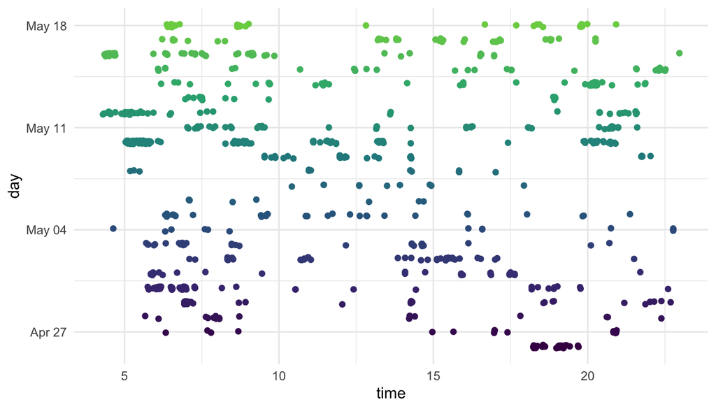

```r
djt %>% transmute(when = created_at - hours(6)) %>%
    mutate(time = hour(when) + minute(when)/60, day = floor_date(when,
        "day")) %>% ggplot(aes(x = time, y = day, colour = as.numeric(day))) +
    geom_jitter(show.legend = FALSE, width = 0, height = 10000) +
    scale_colour_viridis_c(end = 0.8) + theme_minimal()
```

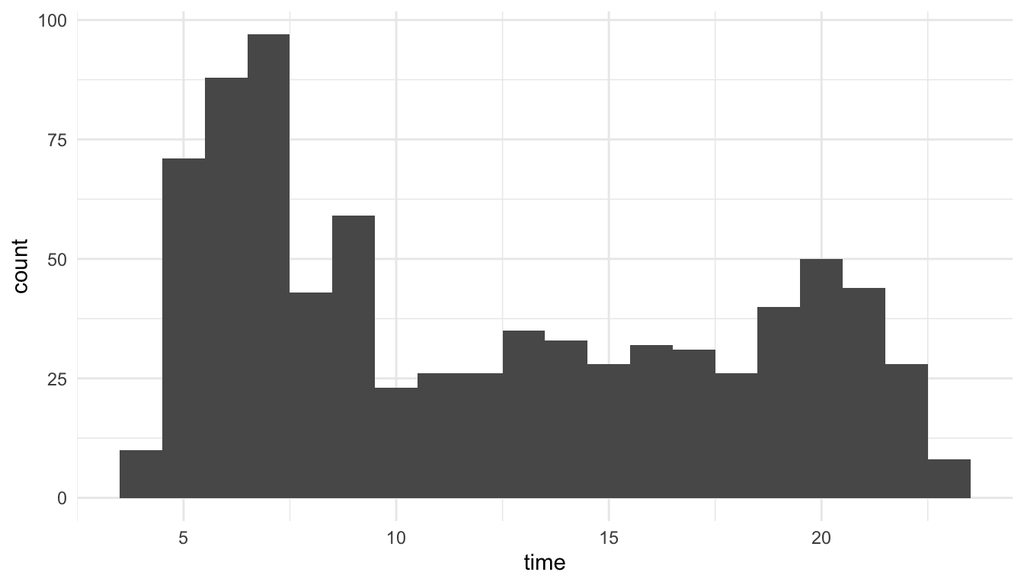

```r
djt %>% transmute(when = created_at - hours(6)) %>%
    mutate(time = hour(when) + minute(when)/60) %>%
    ggplot(aes(x = time)) + stat_bin(binwidth = 1) +
    theme_minimal()
```

```r
djt %>% select(text) %>% tidytext::unnest_tokens("word",
    "text") %>% count(word) %>% arrange(desc(n)) %>%
    anti_join(bind_rows(tidytext::stop_words, tibble(word = c("https",
        "amp", "t.co"))))
```

```
## # A tibble: 3,839 x 2
##    word                n
##    <chr>           <int>
##  1 flynn              75
##  2 president          70
##  3 realdonaldtrump    69
##  4 trump              67
##  5 news               64
##  6 people             58
##  7 fbi                52
##  8 fake               51
##  9 obama              44
## 10 coronavirus        41
## # … with 3,829 more rows
```

# Exercise

- Write code to search for something interesting on Twitter

```r
library(tidyverse)
library(rtweet)
search_tweets( '[ your code goes here ]' )
```

- Try plotting the results with ggplot2
- Suggestions:
  - Number of tweets about an unusual news item over time
  - Occurrences of `#hashtag` by time of day
  - Be creative, or don’t — just get some practice

# Before the next session

```r
install.packages("tm", dependencies = TRUE)
install.packages("topicmodels", dependencies = TRUE)
```

- Read and follow (type along with) this tutorial if you haven’t already

  ```r
  vignette("tm", package = "tm")
  ```

  (or https://cran.r-project.org/web/packages/tm/vignettes/tm.pdf if that doesn’t work…)
- Skim pp 1–7 of [Gonçalves, et al. “A Benchmark Comparison of State-of-the-Practice Sentiment Analysis Methods.” arXiv preprint arXiv:1512.01818 (2015). http://arxiv.org/pdf/1512.01818.pdf](http://arxiv.org/pdf/1512.01818.pdf)